# Fantasy_Football_projections

Brain storming: topic - fantasy football projections

I want to find statistical indicators of good fantasy football performance

what are stats that correlate to good fantasy football production?

This is a broad question. To start we will focus on Wide Recievers and Tight Ends, broadly known as pass catchers.

The type of league can have a huge impact on the fantasy output as well. The main 3 types of scoring format are standard, half points per reception, and full points per reception (PPR).

For standard, a fantasy football score is determined by yards and TDs. For half-PPR and full PPR leagues, a fantasy football score is determined by yards, TDs, and receptions.

This is an example for a WR/TE ex:

- Standard - if a player has 3 receptions, 55 yards, and 1 touchdown they will have 5.5 (1 point per 10 yards) + 6 points (6 points per TD) = 11.5 points
- Half PPR - if a player has 3 receptions, 55 yards, and 1 touchdown they will have 5.5 (1 point per 10 yards) + 6 points (6 points per TD) + 1.5 (half a point per reception) = 13 points
- Full PPR - if a player has 3 receptions, 55 yards, and 1 touchdown they will have 5.5 (1 point per 10 yards) + 6 points (6 points per TD) + 3 (1 point per reception) = 14.5 points

To start lets gather the top scrimmage yard leaders in the NFL

```python
#import libraries needed

from sklearn.linear_model import LinearRegression
import requests
from bs4 import BeautifulSoup
import pandas as pd
import numpy as np
import matplotlib.pyplot as plt
```

We will start by pulling data from pro football reference. This website has up-to-date statistics on various aspects about the NFL.

```python
#get the url
nfl_url = "https://www.pro-football-reference.com/years/2022/scrimmage.htm"

#ESPN data
#year = 2022
#league_id = '1571831857'
#swid = '{8E04BD2C-6729-4D7F-A097-9BEE26ADA920}'
#espn_s2 = 'AEAVoRBHHwBdTj4OFKC65JBxbepvMyHDOr%2F0MU%2BRYxSwW%2FNSuwiV5DmAS2zOzZ7zytB6jDU05zVM5Rj8cF0TW1JuCBMniCFZ8L%2F6Mzz8osxjuV63nAW1njsOkqVTN7h0RoYazk9irPVJjD6Kz5cVKecW8U4U6Zoerx4BqaHjA57j1h4nUefp13F9a8vjT4pY9px4kHHarNt7ZUX1MbgzMoAmmM7azCsFzfqnmyHvCVVFzxiaB3dMLru5zoeyWZx8eVIo4IzbGNG%2FGcs5E%2FYfyuzNnF6fUMmwHzUiVEkF%2BP%2BVAL6lpspQ8jUCdIDk6%2F%2FgynE%3D'
#fantasy_url = f"https://fantasy.espn.com/apis/v3/games/ffl/seasons/{year}/segments/0/leagues/{league_id}"
```

```python
#request access to data
nfl_page = requests.get(nfl_url)
#fantasy_page = requests.get(fantasy_url, cookies = { "swid" : swid, "espn_s2": espn_s2 })
```

```python
#parse  HTML for table we want
nfl_soup = BeautifulSoup(nfl_page.text, 'lxml')
#nfl_soup
nfl_table = nfl_soup.find('table', id='receiving_and_rushing')

#code obsolete
#fantasy_soup = BeautifulSoup(fantasy_page.text, 'lxml')
#fantasy_soup
#fantasy_table = fantasy_soup.find('table')
#fantasy_table
```

```python
#nfl reference headers in table
nfl_headers = []
for i in nfl_table.find_all('th'):
  title = i.text
  nfl_headers.append(title)

#renaming headers to differentiate between recieving and rushing
nfl_headers[16] = 'RecYds'
nfl_headers[18] = 'RecTD'
nfl_headers[19] = 'Rec1D'
nfl_headers[20] = 'RecLng'
nfl_headers[22] = 'Rec_Y/G'
nfl_headers[26] = 'RushYds'
nfl_headers[27] = 'RushTD'
nfl_headers[28] = 'Rush1D'
nfl_headers[29] = 'RushLng'
nfl_headers[31] = 'Rush_Y/G'
```

```python
#grab just the headers we want for table
nfl_data = pd.DataFrame(columns = nfl_headers[7:38])
```

```python
#table for real nfl stats
for j in nfl_table.find_all('tr')[1:]:
  row_data_th = j.find_all('th')
  row_data_tr = j.find_all('td')
  row_data = row_data_th + row_data_tr
  row = [i.text for i in row_data]
  length = len(nfl_data)
  nfl_data.loc[length] = row
```

```python
#helper method to turn stats of string type to float
def is_float(string):
    try:
        float(string)
        return True
    except ValueError:
        return False
```

Only skill players (RB, WR, TE) with over 10 yards will qualify for my table

```python
#clean the data
for index, row in nfl_data.iterrows():
  count = row['Player'].count('*') + row['Player'].count('+')
  name = row['Player']
  row['Player'] = name.replace('*', '').replace('+', '')

for index, row in nfl_data.iterrows():

  if row['Rk'] == 'Rk':
    nfl_data.drop(index, inplace=True)

  elif row['YScm'].isdigit() and int(row['YScm']) < 10:
    nfl_data.drop(index, inplace=True)

  elif row['Pos'] == 'QB':
    nfl_data.drop(index, inplace=True)

  elif int(row['G']) < 3:
    nfl_data.drop(index, inplace=True)

  if len(row['Fmb']) == 0:
    nfl_data = nfl_data.replace(row['Fmb'], '0')
  if len(row['Rec']) == 0:
    nfl_data = nfl_data.replace(row['Rec'], '0')

  if row['RRTD'].isdigit():
    nfl_data = nfl_data.replace(row['RRTD'], int(row['RRTD']))

nfl_data = nfl_data.reset_index(drop=True)
#nfl_data.to_string()
pd.set_option('display.max_rows', None)

nfl_data[:10]
```

|  | Rk | Player | Tm | Age | Pos | G | GS | Tgt | Rec | RecYds | Y/R | RecTD | Rec1D | RecLng | R/G | Rec_Y/G | Ctch% | Y/Tgt | Att | RushYds | RushTD | Rush1D | RushLng | Y/A | Rush_Y/G | A/G | Touch | Y/Tch | YScm | … |
| --- | --- | --- | --- | --- | --- | --- | --- | --- | --- | --- | --- | --- | --- | --- | --- | --- | --- | --- | --- | --- | --- | --- | --- | --- | --- | --- | --- | --- | --- | --- |
| 0 | 1 | Josh Jacobs | LVR | 24 | RB | 17 | 17 | 64 | 53 | 400 | 7.5 | 0 | 16 | 43 | 3.1 | 23.5 | 82.8% | 6.3 | 340 | 1653 | 12 | 93 | 86 | 4.9 | 97.2 | 20.0 | 393 | 5.2 | 2053 | … |
| 1 | 2 | Derrick Henry | TEN | 28 | RB | 16 | 16 | 41 | 33 | 398 | 12.1 | 0 | 11 | 69 | 2.1 | 24.9 | 80.5% | 9.7 | 349 | 1538 | 13 | 65 | 56 | 4.4 | 96.1 | 21.8 | 382 | 5.1 | 1936 | … |
| 2 | 3 | Christian McCaffrey | 2TM | 26 | RB | 17 | 16 | 108 | 85 | 741 | 8.7 | 5 | 36 | 49 | 5.0 | 43.6 | 78.7% | 6.9 | 244 | 1139 | 8 | 59 | 49 | 4.7 | 67.0 | 14.4 | 329 | 5.7 | 1880 | … |
| 3 | 4 | Justin Jefferson | MIN | 23 | WR | 17 | 17 | 184 | 128 | 1809 | 14.1 | 8 | 80 | 64 | 7.5 | 106.4 | 69.6% | 9.8 | 4 | 24 | 1 | 2 | 10 | 6.0 | 1.4 | 0.2 | 132 | 13.9 | 1833 | … |
| 4 | 5 | Nick Chubb | CLE | 27 | RB | 17 | 17 | 37 | 27 | 239 | 8.9 | 1 | 12 | 26 | 1.6 | 14.1 | 73.0% | 6.5 | 302 | 1525 | 12 | 69 | 41 | 5.0 | 89.7 | 17.8 | 329 | 5.4 | 1764 | … |
| 5 | 6 | Tyreek Hill | MIA | 28 | WR | 17 | 17 | 170 | 119 | 1710 | 14.4 | 7 | 77 | 64 | 7.0 | 100.6 | 70.0% | 10.1 | 7 | 32 | 1 | 3 | 10 | 4.6 | 1.9 | 0.4 | 126 | 13.8 | 1742 | … |
| 6 | 7 | Saquon Barkley | NYG | 25 | RB | 16 | 16 | 76 | 57 | 338 | 5.9 | 0 | 10 | 41 | 3.6 | 21.1 | 75.0% | 4.4 | 295 | 1312 | 10 | 62 | 68 | 4.4 | 82.0 | 18.4 | 352 | 4.7 | 1650 | … |
| 7 | 8 | Austin Ekeler | LAC | 27 | RB | 17 | 17 | 127 | 107 | 722 | 6.7 | 5 | 36 | 23 | 6.3 | 42.5 | 84.3% | 5.7 | 204 | 915 | 13 | 46 | 72 | 4.5 | 53.8 | 12.0 | 311 | 5.3 | 1637 | … |
| 8 | 9 | Aaron Jones | GNB | 28 | RB | 17 | 17 | 72 | 59 | 395 | 6.7 | 5 | 19 | 30 | 3.5 | 23.2 | 81.9% | 5.5 | 213 | 1121 | 2 | 54 | 36 | 5.3 | 65.9 | 12.5 | 272 | 5.6 | 1516 | … |
| 9 | 10 | Davante Adams | LVR | 30 | WR | 17 | 17 | 180 | 100 | 1516 | 15.2 | 14 | 65 | 60 | 5.9 | 89.2 | 55.6% | 8.4 | 3 | -1 | 0 | 0 | 4 | -0.3 | -0.1 | 0.2 | 103 | 14.7 | 1515 | … |

Since all 3 types of scoring are widely used. I will use the middle ground for our data (half PPR).

Calculating the data myself will have a few flaws. First off, any obsecure way a player gained fantasy points will not be included (for example, scoring on a 2pt conversion, or scoring on a punt/kickoff return). In addition, the 18 week of the regular season is usually a very inaccurate week to look at for stats as many teams are not playing their starters 100% as they tank for the draft or get ready for the playoffs.

```python
#calculate fantasy points per game and total fantasy points. Add both columns to table.
fppg = []
fp_total = []
for index, row in nfl_data.iterrows():
  fantasy_points = (int(row['RRTD']) * 6) + (int(row['YScm']) * .1) + (int(row['Rec']) * .5) + (int(row['Fmb']) * -2)
  avg = fantasy_points / int(row['G'])
  fp_total.append(fantasy_points)
  fppg.append(avg)

nfl_data['FPPG'] = fppg
nfl_data["FPT"] = fp_total

for index, row in nfl_data.iterrows():
  nfl_data = nfl_data.replace(row['FPPG'], np.round(row['FPPG'], 2))
  nfl_data = nfl_data.replace(row['FPT'], np.round(row['FPT'], 2))
  if row['FPPG'] < 4:
    nfl_data.drop(index, inplace=True)

#sort my fantasy table data by fantasy point per game
nfl_data = nfl_data.sort_values(by=['FPT'], ascending=False)
nfl_data = nfl_data.reset_index(drop=True)
nfl_data[:10]
```

|  | Rk | Player | Tm | Age | Pos | G | GS | Tgt | Rec | RecYds | Y/R | RecTD | Rec1D | RecLng | R/G | Rec_Y/G | Ctch% | Y/Tgt | Att | RushYds | RushTD | Rush1D | RushLng | Y/A | Rush_Y/G | A/G | Touch | Y/Tch | YScm | … |
| --- | --- | --- | --- | --- | --- | --- | --- | --- | --- | --- | --- | --- | --- | --- | --- | --- | --- | --- | --- | --- | --- | --- | --- | --- | --- | --- | --- | --- | --- | --- |
| 0 | 8.0 | Austin Ekeler | LAC | 27 | RB | 17 | 17 | 127 | 107 | 722 | 6.7 | 5 | 36 | 23 | 6.3 | 42.5 | 84.3% | 5.7 | 204 | 915 | 13.0 | 46 | 72 | 4.5 | 53.8 | 12.0 | 311 | 5.3 | 1637 | … |
| 1 | 3.0 | Christian McCaffrey | 2TM | 26 | RB | 17 | 16 | 108 | 85 | 741 | 8.7 | 5 | 36 | 49 | 5.0 | 43.6 | 78.7% | 6.9 | 244 | 1139 | 8.0 | 59 | 49 | 4.7 | 67.0 | 14.4 | 329 | 5.7 | 1880 | … |
| 2 | 4.0 | Justin Jefferson | MIN | 23 | WR | 17 | 17 | 184 | 128 | 1809 | 14.1 | 8 | 80 | 64 | 7.5 | 106.4 | 69.6% | 9.8 | 4.0 | 24 | 1.0 | 2.0 | 10.0 | 6.0 | 1.4 | 0.2 | 132 | 13.9 | 1833 | … |
| 3 | 1.0 | Josh Jacobs | LVR | 24 | RB | 17 | 17 | 64 | 53 | 400 | 7.5 | 0 | 16 | 43 | 3.1 | 23.5 | 82.8% | 6.3 | 340 | 1653 | 12.0 | 93 | 86 | 4.9 | 97.2 | 20.0 | 393 | 5.2 | 2053 | … |
| 4 | 10.0 | Davante Adams | LVR | 30 | WR | 17 | 17 | 180 | 100 | 1516 | 15.2 | 14 | 65 | 60 | 5.9 | 89.2 | 55.6% | 8.4 | 3.0 | -1 | 0.0 | 0 | 4.0 | -0.3 | -0.1 | 0.2 | 103 | 14.7 | 1515 | … |
| 5 | 6.0 | Tyreek Hill | MIA | 28 | WR | 17 | 17 | 170 | 119 | 1710 | 14.4 | 7 | 77 | 64 | 7.0 | 100.6 | 70.0% | 10.1 | 7.0 | 32 | 1.0 | 3.0 | 10.0 | 4.6 | 1.9 | 0.4 | 126 | 13.8 | 1742 | … |
| 6 | 2.0 | Derrick Henry | TEN | 28 | RB | 16 | 16 | 41 | 33 | 398 | 12.1 | 0 | 11 | 69 | 2.1 | 24.9 | 80.5% | 9.7 | 349 | 1538 | 13.0 | 65 | 56 | 4.4 | 96.1 | 21.8 | 382 | 5.1 | 1936 | … |
| 7 | 5.0 | Nick Chubb | CLE | 27 | RB | 17 | 17 | 37 | 27 | 239 | 8.9 | 1 | 12 | 26 | 1.6 | 14.1 | 73.0% | 6.5 | 302 | 1525 | 12.0 | 69 | 41 | 5.0 | 89.7 | 17.8 | 329 | 5.4 | 1764 | … |
| 8 | 15 | Stefon Diggs | BUF | 29 | WR | 16 | 16 | 154 | 108 | 1429 | 13.2 | 11 | 74 | 53 | 6.8 | 89.3 | 70.1% | 9.3 | 1.0 | -3 | 0.0 | 0 | -3 | -3.0 | -0.2 | 0.1 | 109 | 13.1 | 1426 | … |
| 9 | 21 | Travis Kelce | KAN | 33 | TE | 17 | 17 | 152 | 110 | 1338 | 12.2 | 12 | 78 | 52 | 6.5 | 78.7 | 72.4% | 8.8 | 2.0 | 5.0 | 0.0 | 1.0 | 4.0 | 2.5 | 0.3 | 0.1 | 112 | 12.0 | 1343 | … |

```python
#create tables for Recievers and Runningbacks
rec_data = nfl_data.copy(deep=True)
run_data = nfl_data.copy(deep=True)

for index, row in rec_data.iterrows():
  if row['Pos'] == 'WR':
    if is_float(str(row['Y/R'])):
      rec_data = rec_data.replace(row['Y/R'], float(row['Y/R']))
    if int(row['Rec']) < 15:
      rec_data.drop(index, inplace=True)
  elif row['Pos'] == 'TE':
    if is_float(str(row['Y/R'])):
      rec_data = rec_data.replace(row['Y/R'], float(row['Y/R']))
    if int(row['Rec']) < 15:
      rec_data.drop(index, inplace=True)
  else:
    rec_data.drop(index, inplace=True)

  #[Rk, Player, Tm, Age, Pos, G, GS, Tgt, Rec, RecYds, Y/R, RecTD, Rec1D, RecLng, R/G, Rec_Y/G, Ctch%, Y/Tgt, Att, RushYds, RushTD, Rush1D, RushLng, Y/A, Rush_Y/G, A/G, Touch, Y/Tch, YScm, RRTD, Fmb]

rec_data = rec_data.drop(['Att', 'RushYds', 'RushTD', 'Rush1D', 'RushLng', 'Y/A', 'Rush_Y/G', 'A/G', 'Touch', 'Y/Tch', 'YScm', 'RRTD'], axis=1)

for index, row in run_data.iterrows():
  if row['Pos'] != 'RB':
    run_data.drop(index, inplace=True)

pd.set_option('display.max_columns', None)
rec_data[:10]
```

|  | Rk | Player | Tm | Age | Pos | G | GS | Tgt | Rec | RecYds | Y/R | RecTD | Rec1D | RecLng | R/G | Rec_Y/G | Ctch% | Y/Tgt | Fmb | FPPG | FPT |
| --- | --- | --- | --- | --- | --- | --- | --- | --- | --- | --- | --- | --- | --- | --- | --- | --- | --- | --- | --- | --- | --- |
| 2 | 4.0 | Justin Jefferson | MIN | 23 | WR | 17 | 17 | 184 | 128 | 1809 | 14.1 | 8 | 80 | 64 | 7.5 | 106.4 | 69.6% | 9.8 | 0 | 17.72 | 301.3 |
| 4 | 10.0 | Davante Adams | LVR | 30 | WR | 17 | 17 | 180 | 100 | 1516 | 15.2 | 14 | 65 | 60 | 5.9 | 89.2 | 55.6% | 8.4 | 1 | 16.68 | 283.5 |
| 5 | 6.0 | Tyreek Hill | MIA | 28 | WR | 17 | 17 | 170 | 119 | 1710 | 14.4 | 7 | 77 | 64 | 7.0 | 100.6 | 70.0% | 10.1 | 1 | 16.45 | 279.7 |
| 8 | 15 | Stefon Diggs | BUF | 29 | WR | 16 | 16 | 154 | 108 | 1429 | 13.2 | 11 | 74 | 53 | 6.8 | 89.3 | 70.1% | 9.3 | 1 | 16.29 | 260.6 |
| 9 | 21 | Travis Kelce | KAN | 33 | TE | 17 | 17 | 152 | 110 | 1338 | 12.2 | 12 | 78 | 52 | 6.5 | 78.7 | 72.4% | 8.8 | 1 | 15.25 | 259.3 |
| 10 | 11 | A.J. Brown | PHI | 25 | WR | 17 | 16 | 145 | 88 | 1496 | 17.0 | 11 | 59 | 78 | 5.2 | 88.0 | 60.7% | 10.3 | 2 | 15.04 | 255.6 |
| 12 | 16 | CeeDee Lamb | DAL | 23 | WR | 17 | 17 | 156 | 107 | 1359 | 12.7 | 9 | 67 | 39 | 6.3 | 79.9 | 68.6% | 8.7 | 0 | 14.59 | 248.1 |
| 14 | 18.0 | Jaylen Waddle | MIA | 24 | WR | 17 | 17 | 117 | 75 | 1356 | 18.1 | 8 | 60 | 84 | 4.4 | 79.8 | 64.1% | 11.6 | 1 | 13.04 | 221.7 |
| 17 | 23 | Amon-Ra St. Brown | DET | 23 | WR | 16 | 16 | 146 | 106 | 1161 | 11.0 | 6 | 68 | 49 | 6.6 | 72.6 | 72.6% | 8.0 | 0 | 13.41 | 214.6 |
| 20 | 30 | Amari Cooper | CLE | 28 | WR | 17 | 17 | 132 | 78 | 1160 | 14.9 | 9 | 61 | 55 | 4.6 | 68.2 | 59.1% | 8.8 | 0 | 12.29 | 209.0 |

Second, we will pull data from Pro Fantasy Football. This website focuses on the fantasy aspect of football. This allows us to get the total fantasy points of an individual player based on Half PPR scoring . This is the official number of points a player scored for half PPR.

```python
#get pff football data to compare fantasy score outputs (response 200)
pff_url = "https://www.fantasypros.com/nfl/reports/leaders/half-ppr.php?year=2022"
pff_page = requests.get(pff_url)
```

```python
#parse HTML for table we want
pff_soup = BeautifulSoup(pff_page.text, 'lxml')
pff_soup
pff_table = pff_soup.find('table', id='data')
```

```python
#pff headers
pff_headers = []
for k in pff_table.find_all('th'):
  title = k.text
  pff_headers.append(title)
```

```python
#grab headers we want for dataframe
pff_data = pd.DataFrame(columns = pff_headers)
```

```python
#create dataframe
for j in pff_table.find_all('tr')[1:]:
  row_data = j.find_all('td')
  row = [k.text for k in row_data]
  length = len(pff_data)
  pff_data.loc[length] = row
```

```python
#clean data
for index, row in pff_data.iterrows():
  if row['Pos'] == 'QB' or row['Pos'] == 'DST' or row['Pos'] == 'K' or row['Pos'] == 'RB':
    pff_data.drop(index, inplace=True)

  elif float(row['TTL']) < 10:
    pff_data.drop(index, inplace=True)

  if is_float(str(row['TTL'])):
      pff_data = pff_data.replace(row['TTL'], np.round(float(row['TTL']), 2))

pff_data[:5]
```

|  | # | Player | Pos | Team | 1 | 2 | 3 | 4 | 5 | 6 | 7 | 8 | 9 | 10 | 11 | 12 | 13 | 14 | 15 | 16 | 17 | 18 | AVG | TTL |
| --- | --- | --- | --- | --- | --- | --- | --- | --- | --- | --- | --- | --- | --- | --- | --- | --- | --- | --- | --- | --- | --- | --- | --- | --- |
| 9 | 10.0 | Justin Jefferson | WR | MIN | 34.9 | 7.8 | 2.9 | 26.0 | 24.3 | 13.7 | BYE | 12.8 | 22.0 | 30.3 | 4.8 | 24.8 | 15.1 | 27.8 | 24.3 | 25.3 | 2.0 | 5.8 | 17.9 | 304.7 |
| 16 | 17 | Davante Adams | WR | LV | 25.1 | 8.2 | 11.7 | 15.0 | 25.9 | BYE | 13.5 | 0.7 | 31.6 | 23.1 | 29.6 | 10.9 | 33.7 | 8.6 | 4.8 | 2.5 | 30.8 | 9.8 | 16.8 | 285.5 |
| 17 | 18.0 | Tyreek Hill | WR | MIA | 14.0 | 36.5 | 4.3 | 20.9 | 9.5 | 23.7 | 10.7 | 25.5 | 23.8 | 12.9 | BYE | 12 | 25.1 | 16.1 | 17.4 | 12.3 | 13.7 | 3.3 | 16.6 | 281.7 |
| 20 | 21 | Stefon Diggs | WR | BUF | 22.2 | 38.8 | 10.9 | 8.2 | 20.2 | 25.8 | BYE | 19.8 | 11.8 | 18.8 | 12.8 | 17.7 | 18.7 | 5.2 | 8.2 | 3.6 | 3.6 | 19.9 | 15.7 | 266.2 |
| 21 | 22.0 | Travis Kelce | TE | KC | 22.1 | 7.6 | 15.9 | 19.7 | 30 | 15.2 | 12.8 | BYE | 15.6 | 17.1 | 32.5 | 13.7 | 5.6 | 9.1 | 15.5 | 14.3 | 7.8 | 6.8 | 15.4 | 261.3 |

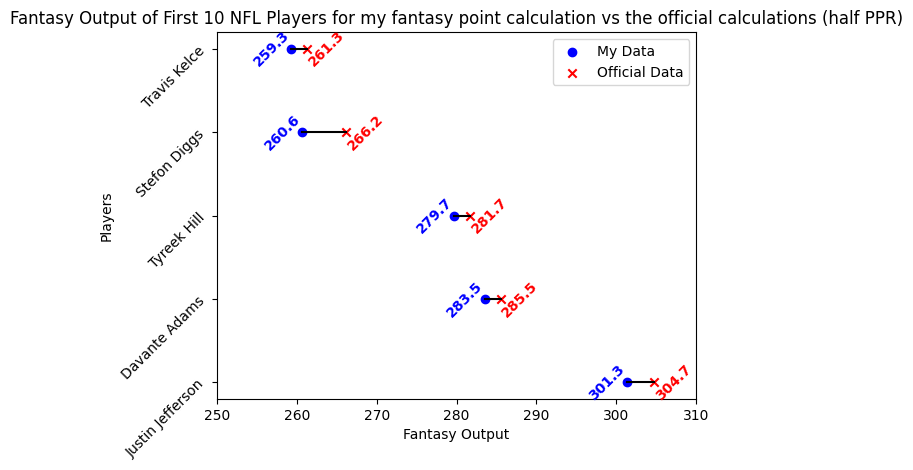

```python
players = list(rec_data[:5]['Player'])
my_data = list(rec_data[:5]['FPT'])
official_data = list(pff_data[:5]['TTL'])

plt.scatter(my_data, players, marker='o', color='blue', label='My Data', zorder=2)
plt.scatter(official_data, players, marker='x', color='red', label='Official Data', zorder=2)
for i in range(5):
    plt.plot([my_data[i], official_data[i]], [players[i], players[i]], 'k-')
for x, y, my, official in zip(my_data, players, my_data, official_data):
    plt.text(x - 5, y, str(my), ha='left', va='center', color='blue', fontweight='bold', rotation = 45)
    plt.text(official + 5, y, str(official), ha='right', va='center', color='red', fontweight='bold', rotation = 45)

plt.ylabel('Players')
plt.xlabel('Fantasy Output')
plt.title('Fantasy Output of First 10 NFL Players for my fantasy point calculation vs the official calculations (half PPR)')
plt.xlim(250, 310)
plt.legend()
plt.yticks(rotation=45)
plt.tight_layout()
plt.show()
```

As you can see from comparing both tables and the graph, while there are some anomolies that slightly change the the Fantasy points per game / fantasy point total, it is relatively similar.

This is a relatively small example of just 5 players. If we look at other cases, some players came out with the exact same score, while others had a lower official score compared to my calculations by a small margin.

Now that we understand why we are using an objective calculation of fantasy output rather than the official numbers. Lets take a look at statistic that we expected to be heavily correlated with fantasy point output, total touchdowns (This will include all skill players).

```python
#sort data by fantasy points per game. I can allows players who got injured for some part of the year to be included where they would be projecting a full season
nfl_data = nfl_data.sort_values(by=['FPPG'], ascending=False)
nfl_data = nfl_data.reset_index(drop=True)
nfl_data[:10]
```

|  | Rk | Player | Tm | Age | Pos | G | GS | Tgt | Rec | RecYds | Y/R | RecTD | Rec1D | RecLng | R/G | Rec_Y/G | Ctch% | Y/Tgt | Att | RushYds | RushTD | Rush1D | RushLng | Y/A | Rush_Y/G | A/G | Touch | Y/Tch | YScm | … |
| --- | --- | --- | --- | --- | --- | --- | --- | --- | --- | --- | --- | --- | --- | --- | --- | --- | --- | --- | --- | --- | --- | --- | --- | --- | --- | --- | --- | --- | --- | --- |
| 0 | 8.0 | Austin Ekeler | LAC | 27 | RB | 17 | 17 | 127 | 107 | 722 | 6.7 | 5 | 36 | 23 | 6.3 | 42.5 | 84.3% | 5.7 | 204 | 915 | 13.0 | 46 | 72 | 4.5 | 53.8 | 12.0 | 311 | 5.3 | 1637 | … |
| 1 | 3.0 | Christian McCaffrey | 2TM | 26 | RB | 17 | 16 | 108 | 85 | 741 | 8.7 | 5 | 36 | 49 | 5.0 | 43.6 | 78.7% | 6.9 | 244 | 1139 | 8.0 | 59 | 49 | 4.7 | 67.0 | 14.4 | 329 | 5.7 | 1880 | … |
| 2 | 66 | Cooper Kupp | LAR | 29 | WR | 9.0 | 9.0 | 98 | 75 | 812 | 10.8 | 6 | 42 | 75 | 8.3 | 90.2 | 76.5% | 8.3 | 9.0 | 52 | 1.0 | 4.0 | 20 | 5.8 | 5.8 | 1.0 | 84 | 10.3 | 864 | … |
| 3 | 4.0 | Justin Jefferson | MIN | 23 | WR | 17 | 17 | 184 | 128 | 1809 | 14.1 | 8 | 80 | 64 | 7.5 | 106.4 | 69.6% | 9.8 | 4.0 | 24 | 1.0 | 2.0 | 10.0 | 6.0 | 1.4 | 0.2 | 132 | 13.9 | 1833 | … |
| 4 | 1.0 | Josh Jacobs | LVR | 24 | RB | 17 | 17 | 64 | 53 | 400 | 7.5 | 0 | 16 | 43 | 3.1 | 23.5 | 82.8% | 6.3 | 340 | 1653 | 12.0 | 93 | 86 | 4.9 | 97.2 | 20.0 | 393 | 5.2 | 2053 | … |
| 5 | 2.0 | Derrick Henry | TEN | 28 | RB | 16 | 16 | 41 | 33 | 398 | 12.1 | 0 | 11 | 69 | 2.1 | 24.9 | 80.5% | 9.7 | 349 | 1538 | 13.0 | 65 | 56 | 4.4 | 96.1 | 21.8 | 382 | 5.1 | 1936 | … |
| 6 | 10.0 | Davante Adams | LVR | 30 | WR | 17 | 17 | 180 | 100 | 1516 | 15.2 | 14 | 65 | 60 | 5.9 | 89.2 | 55.6% | 8.4 | 3.0 | -1 | 0.0 | 0 | 4.0 | -0.3 | -0.1 | 0.2 | 103 | 14.7 | 1515 | … |
| 7 | 41 | Ja'Marr Chase | CIN | 22 | WR | 12 | 12 | 134 | 87 | 1046 | 12.0 | 9 | 58 | 60 | 7.3 | 87.2 | 64.9% | 7.8 | 5.0 | 8.0 | 0.0 | 0 | 6.0 | 1.6 | 0.7 | 0.4 | 92 | 11.5 | 1054 | … |
| 8 | 6.0 | Tyreek Hill | MIA | 28 | WR | 17 | 17 | 170 | 119 | 1710 | 14.4 | 7 | 77 | 64 | 7.0 | 100.6 | 70.0% | 10.1 | 7.0 | 32 | 1.0 | 3.0 | 10.0 | 4.6 | 1.9 | 0.4 | 126 | 13.8 | 1742 | … |
| 9 | 15 | Stefon Diggs | BUF | 29 | WR | 16 | 16 | 154 | 108 | 1429 | 13.2 | 11 | 74 | 53 | 6.8 | 89.3 | 70.1% | 9.3 | 1.0 | -3 | 0.0 | 0 | -3 | -3.0 | -0.2 | 0.1 | 109 | 13.1 | 1426 | … |

```python
#sort data by fantasy points per game. I can allows players who got injured for some part of the year to be included where they would be projecting a full season
rec_data = rec_data.sort_values(by=['FPPG'], ascending=False)
rec_data = rec_data.reset_index(drop=True)
rec_data[:10]
```

|  | Rk | Player | Tm | Age | Pos | G | GS | Tgt | Rec | RecYds | Y/R | RecTD | Rec1D | RecLng | R/G | Rec_Y/G | Ctch% | Y/Tgt | Fmb | FPPG | FPT |
| --- | --- | --- | --- | --- | --- | --- | --- | --- | --- | --- | --- | --- | --- | --- | --- | --- | --- | --- | --- | --- | --- |
| 0 | 66 | Cooper Kupp | LAR | 29 | WR | 9.0 | 9.0 | 98 | 75 | 812 | 10.8 | 6 | 42 | 75 | 8.3 | 90.2 | 76.5% | 8.3 | 2 | 17.99 | 161.9 |
| 1 | 4.0 | Justin Jefferson | MIN | 23 | WR | 17 | 17 | 184 | 128 | 1809 | 14.1 | 8 | 80 | 64 | 7.5 | 106.4 | 69.6% | 9.8 | 0 | 17.72 | 301.3 |
| 2 | 10.0 | Davante Adams | LVR | 30 | WR | 17 | 17 | 180 | 100 | 1516 | 15.2 | 14 | 65 | 60 | 5.9 | 89.2 | 55.6% | 8.4 | 1 | 16.68 | 283.5 |
| 3 | 41 | Ja'Marr Chase | CIN | 22 | WR | 12 | 12 | 134 | 87 | 1046 | 12.0 | 9 | 58 | 60 | 7.3 | 87.2 | 64.9% | 7.8 | 2 | 16.58 | 198.9 |
| 4 | 6.0 | Tyreek Hill | MIA | 28 | WR | 17 | 17 | 170 | 119 | 1710 | 14.4 | 7 | 77 | 64 | 7.0 | 100.6 | 70.0% | 10.1 | 1 | 16.45 | 279.7 |
| 5 | 15 | Stefon Diggs | BUF | 29 | WR | 16 | 16 | 154 | 108 | 1429 | 13.2 | 11 | 74 | 53 | 6.8 | 89.3 | 70.1% | 9.3 | 1 | 16.29 | 260.6 |
| 6 | 21 | Travis Kelce | KAN | 33 | TE | 17 | 17 | 152 | 110 | 1338 | 12.2 | 12 | 78 | 52 | 6.5 | 78.7 | 72.4% | 8.8 | 1 | 15.25 | 259.3 |
| 7 | 11 | A.J. Brown | PHI | 25 | WR | 17 | 16 | 145 | 88 | 1496 | 17.0 | 11 | 59 | 78 | 5.2 | 88.0 | 60.7% | 10.3 | 2 | 15.04 | 255.6 |
| 8 | 16 | CeeDee Lamb | DAL | 23 | WR | 17 | 17 | 156 | 107 | 1359 | 12.7 | 9 | 67 | 39 | 6.3 | 79.9 | 68.6% | 8.7 | 0 | 14.59 | 248.1 |
| 9 | 287 | Michael Thomas | NOR | 29 | WR | 3.0 | 3.0 | 22 | 16 | 171 | 10.7 | 3 | 13 | 21 | 5.3 | 57.0 | 72.7% | 7.8 | 0 | 14.37 | 43.1 |

```python
#do analysis -> linear regression between total tounchdowns scored and fantasy point output

nfl_data['TDPG'] = nfl_data.apply(lambda x: np.round(int(x['RRTD']) / int(x['G']), 4), axis = 1)
X = nfl_data['TDPG'].values.reshape(-1, 1)
y = nfl_data['FPPG'].values
np.set_printoptions(suppress=True)

model = LinearRegression()
model.fit(X, y)

coef = model.coef_[0]
intercept = model.intercept_

y_pred = model.predict(X)
```

```python
''' #graphing but i wanted a different graph
plt.figure(figsize=(15,10))

plt.scatter(X.ravel(), y, color='red', label='Data points')
# Add player names next to data points
for i, player in enumerate(nfl_data['Player']):
    print(i)
      plt.text(X[i], y[i], player, ha='center', va='bottom')


plt.plot(X.ravel(), y_pred, color='blue', label='LinReg line: y = ' + str(np.round(coef, 3)) + 'x + ' + str(np.round(intercept, 3)))

plt.xlabel('TDs')
plt.ylabel('FPts')
plt.title('TDs vs. Fpts')
plt.legend()
plt.show()
'''
```

[output not shown]

```python
#graph it
import plotly.express as px
import plotly.graph_objects as go
import plotly.io as pio
#pio.renderers.default = 'colab'
pio.renderers.default = "notebook_connected"
import plotly
plotly.offline.init_notebook_mode(connected=True)

# Create a DataFrame with the player names, TDs, and FPts
df = pd.DataFrame({'Player': nfl_data['Player'], 'TDs': X.ravel(), 'FPts': y, 'GP' : nfl_data['G']})

# Create a scatter plot with hover labels
fig = px.scatter(df, x='TDs', y='FPts', hover_data=['Player', 'GP'], trendline='ols')



# Calculate the linear regression coefficients using NumPy polyfit
slope, intercept = np.polyfit(df['TDs'], df['FPts'], 1)

# y = mx + b
predicted_fpts = slope * df['TDs'] + intercept

# Calculate the residuals (differences between actual FPts and predicted FPts)
residuals = df['FPts'] - predicted_fpts

# Define a threshold to identify outliers (example: 2 standard deviations from the residuals mean)
threshold = 2
outliers = df[abs(residuals) > threshold * residuals.std()]

fig.add_trace(go.Scatter(x=outliers['TDs'], y=outliers['FPts'], mode='markers',
                         text=outliers['Player'] + ', GP: ' + outliers['GP'].astype(str) + '<br>TDPG: ' + outliers['TDs'].astype(str) + ', FPPG: ' + outliers['FPts'].astype(str),
                         marker=dict(color='red', size=10),
                         name='Outlier Players'))



# Update the layout to add axis labels and a title
fig.update_layout(
    xaxis_title='TDs Per Game',
    yaxis_title='FPts Per Game',
    title='TDs Per Game vs. Fpts Per Game',
    height = 900,
    width = 2000
)

# Show the interactive plot
fig.show()
```

[interactive chart not shown]

It's very interesting to look at this data. In my opinion, TDs are very random in any given season, but heavily impact fantasy output. This is shown in the R^2 value of .65. It doesn't have an extremely strong correlation, although it does have some.

Overall, TDs should hold some weight for fantasy output, but it's really hard to know how much they can be used to predict future output.

For example, looking at an outlier above the regression line, you can see Diontae Johnson scored 131.7 half PPR fantasy points without scoring a single touchdown. Compare this to someone who was an outlier below the regression line like Chrisitian Watson. Watson scored 143.6 half PPR fantasy points but has 9 TDs that boosted his output heavily.

Some of the TD scoring can be attributed to random luck, but not entirely. Countless factors go into the likelihood a player scores a TD. A few factors that can have a large impact is 'big play' ability (yards per reception), the skill level of the pass catchers Quarterback, and the amount of redzone targets (pass thrown to them inside the 20 yard line) can show how likely a player is to score a TD.

After going through the first question, it will be easier to look at recievers and running backs separately (at least at first) because the stats differ quite widely between the two. The downside of doing this is the question of is a WR/TE or RB better more valuable for fantasy production will not be answered.

Lets compare the Yards per Reception (Y/R) to fantasy point output for pass catchers.

```python
X = rec_data['Y/R'].values.reshape(-1, 1)
y = rec_data['FPPG'].values
np.set_printoptions(suppress=True)

model = LinearRegression()
model.fit(X, y)

coef = model.coef_[0]
intercept = model.intercept_

y_pred = model.predict(X)

# Create a DataFrame with the player names, Yds/Rec, and FPts
df = pd.DataFrame({'Player': rec_data['Player'], 'Yds/Rec': X.ravel(), 'FPts': y})

# Create a scatter plot with hover labels
fig = px.scatter(df, x='Yds/Rec', y='FPts', hover_data=['Player'], trendline='ols')

# Update the layout to add axis labels and a title
fig.update_layout(
    xaxis_title='Yds/Rec',
    yaxis_title='FPts Per Game',
    title='Yards / Reception vs. FPts Per Game',
    height = 900,
    width = 2000
)

# Show the interactive plot
fig.show()
```

[interactive chart not shown]

Interestingly, it seems Yards per Reception has very little correlation to fantasy production with an R^2 value of .04. Many of the top fantasy producers seem to be in the middle of yards per reception. At the same time there are plenty of middle of the pack recievers with lower fantasy production. This makes it seem like volume may be king for fantasy production.

Lets take a look at volume of targets.

```python
rec_data['Tgt/G'] = rec_data.apply(lambda x: np.round(int(x['Tgt']) / int(x['G']), 4), axis = 1)

X = rec_data['Tgt/G'].values.reshape(-1, 1)
y = rec_data['FPPG'].values
np.set_printoptions(suppress=True)

model = LinearRegression()
model.fit(X, y)

coef = model.coef_[0]
intercept = model.intercept_

y_pred = model.predict(X)

# Create a DataFrame with the player names, Yds/Rec, and FPts
df = pd.DataFrame({'Player': rec_data['Player'], 'Tgt/G': X.ravel(), 'FPPG': y})

# Create a scatter plot with hover labels
fig = px.scatter(df, x='Tgt/G', y='FPPG', hover_data=['Player'], trendline='ols')

# Update the layout to add axis labels and a title
fig.update_layout(
    xaxis_title='Tgt/G',
    yaxis_title='FPPG',
    title='Targets Per Game vs. Fantasy Points Per Game',
    height = 900,
    width = 2000
)

# Show the interactive plot
fig.show()
```

[interactive chart not shown]

As seen in the graph above, targets seem to have strong correlation with fantasy point production (r^2 value of .79). That is not a shock.

So does this mean if most recievers had a large amount of volume, they would produce in fantasy?

For the most part, I'd say yes (in the short term), but you have to ask why certain recievers get more volume than others. That is because they have proven to produce and be talented enough to warrant the amounts of targets given. This is why looking at volume alone without any context can be decieving.

**Currently fleshing out the rest of the project. I plan to do k-means clustering next revolving around different pass catcher archetypes. This is just to show my progress.**

```python
!jupyter nbconvert --to html /content/drive/MyDrive/DS_Fantasy/Fantasy_Football_projections.ipynb
```

```
[NbConvertApp] Converting notebook /content/drive/MyDrive/DS_Fantasy/Fantasy_Football_projections.ipynb to html
[NbConvertApp] Writing 660780 bytes to /content/drive/MyDrive/DS_Fantasy/Fantasy_Football_projections.html
```